# Vanderbilt University Medical Center

Arquinio, Elizabeth / Baltodano, Ronald / Del Aguila, Peter / Morales, Jacqueline

2022-06-25

### **1. Sinopsis**

El presente caso se analiza en base a lo requerido por el Centro Médico de la Universidad de Vanderbilt (VUMC), quienes se encuentran interesados en conocer el volumen de cirugías programadas para poder ajustar la dotación de personal y de materiales requeridos.

Especialmente, se desea mejorar las predicciones de volumen diario de cirugías programadas. Para ello se le asigna a Bose, director de Surgical Business Analytics en VUMC, la tarea de mejorar las predicciones en base a la cantidad de cirugías programadas para realizarse en fechas específicas anteriores a la fecha de la cirugía y la cantidad real de cirugías realizadas el día de la cirugía, durante 48 semanas.

### **2. Problemas**

2.1 Problema general:

- La programación ineficiente de cirugías genera problemas con el uso de recursos.

2.2 Problemas específicos:

- Se desconoce el volumen de cirugías programadas a diario.
- Se desconoce los días de mayor y de menor volumen de cirugías.

### **3. Objetivos**

3.1 Objetivo general:

- Estimar la cantidad óptima de personal quirúrjico e insumos para la cantidad de cirugías diarias estimadas.

3.2 Objetivos específicos:

- Proyectar el volumen diario de cirugías.
- Proyectar los días de mayor y de menor volumen de cirugías.

### **4. Análisis**

```r
Base1 <- readWorkbook("W15168-XLS-ENG.xlsx", sheet = "Sheet1", detectDates = TRUE)
names(Base1)<-c("fec_cirugia","dia_cirugia",28,21,14,13,12,11,10,9,8,7,6,5,4,3,2,1,0)
attach(Base1)
glimpse(Base1)
```

```
## Rows: 241
## Columns: 19
## $ fec_cirugia <date> 2011-10-10, 2011-10-11, 2011-10-12, 2011-10-13, 2011-10-1…
## $ dia_cirugia <chr> "Mon", "Tue", "Wed", "Thu", "Fri", "Mon", "Tue", "Wed", "T…
## $ `28`        <dbl> 38, 35, 26, 28, 31, 41, 44, 32, 33, 20, 32, 40, 26, 34, 32…
## $ `21`        <dbl> 45, 47, 43, 48, 40, 56, 55, 40, 44, 32, 44, 51, 38, 54, 39…
## $ `14`        <dbl> 60, 65, 54, 65, 50, 65, 69, 62, 62, 48, 55, 61, 54, 74, 61…
## $ `13`        <dbl> 63, 68, 62, 70, 50, 69, 74, 66, 66, 48, 59, 65, 63, 75, 61…
## $ `12`        <dbl> 65, 78, 72, 72, 50, 72, 79, 71, 67, 48, 61, 70, 65, 75, 61…
## $ `11`        <dbl> 70, 82, 72, 72, 54, 73, 83, 73, 67, 47, 66, 70, 65, 75, 61…
## $ `10`        <dbl> 73, 82, 72, 72, 62, 77, 83, 73, 79, 52, 69, 70, 65, 78, 64…
## $ `9`         <dbl> 73, 82, 74, 82, 68, 78, 83, 84, 77, 55, 69, 70, 68, 80, 69…
## $ `8`         <dbl> 73, 86, 87, 87, 71, 78, 93, 86, 88, 59, 69, 75, 74, 85, 72…
## $ `7`         <dbl> 80, 89, 94, 91, 73, 80, 92, 87, 90, 61, 69, 80, 81, 91, 74…
## $ `6`         <dbl> 84, 92, 96, 94, 73, 86, 96, 89, 98, 61, 74, 83, 89, 91, 74…
## $ `5`         <dbl> 89, 95, 101, 94, 73, 85, 103, 96, 98, 61, 77, 89, 94, 94, …
## $ `4`         <dbl> 94, 99, 102, 94, 78, 86, 105, 96, 98, 69, 83, 94, 94, 94, …
## $ `3`         <dbl> 98, 99, 102, 97, 83, 92, 105, 96, 105, 72, 85, 96, 94, 96,…
## $ `2`         <dbl> 100, 99, 106, 98, 87, 96, 107, 102, 111, 70, 86, 96, 103, …
## $ `1`         <dbl> 104, 114, 114, 103, 94, 102, 114, 119, 118, 88, 92, 100, 1…
## $ `0`         <dbl> 106, 121, 126, 114, 106, 111, 122, 127, 116, 99, 99, 102, …
```

```r
Base2 <- Base1 %>% gather(dias_atras, nro_cirugias, 3:19)
head(Base2)
```

```
##   fec_cirugia dia_cirugia dias_atras nro_cirugias
## 1  2011-10-10         Mon         28           38
## 2  2011-10-11         Tue         28           35
## 3  2011-10-12         Wed         28           26
## 4  2011-10-13         Thu         28           28
## 5  2011-10-14         Fri         28           31
## 6  2011-10-17         Mon         28           41
```

```r
Base2$dia_cirugia <- as_factor(Base2$dia_cirugia)
Base2$dias_atras <- as.numeric(Base2$dias_atras)
Base2 <- Base2 %>%
        mutate(sem_atras = case_when(
          Base2$dias_atras<=7 ~ 0,
          Base2$dias_atras>7 & Base2$dias_atras<=14 ~ 1,
          Base2$dias_atras>14 & Base2$dias_atras<=21 ~ 2,
          Base2$dias_atras>21 & Base2$dias_atras<=28 ~ 3,
                                 TRUE ~ 4))
Base2$sem_atras <- as.factor(Base2$sem_atras)
levels(Base2$sem_atras) <- c("1. Sem-0","2. Sem-1","3. Sem-2","4. Sem-3")
df_status(Base2)
```

```
##       variable q_zeros p_zeros q_na p_na q_inf p_inf    type unique
## 1  fec_cirugia       0    0.00    0    0     0     0    Date    241
## 2  dia_cirugia       0    0.00    0    0     0     0  factor      5
## 3   dias_atras     241    5.88    0    0     0     0 numeric     17
## 4 nro_cirugias      31    0.76    0    0     0     0 numeric    138
## 5    sem_atras       0    0.00    0    0     0     0  factor      4
```

```r
summary(Base2)
```

```
##   fec_cirugia         dia_cirugia   dias_atras      nro_cirugias
##  Min.   :2011-10-10   Mon:799     Min.   : 0.000   Min.   :  0.00
##  1st Qu.:2012-01-03   Tue:833     1st Qu.: 4.000   1st Qu.: 67.00
##  Median :2012-03-27   Wed:816     Median : 8.000   Median : 83.00
##  Mean   :2012-03-27   Thu:816     Mean   : 9.059   Mean   : 81.11
##  3rd Qu.:2012-06-20   Fri:833     3rd Qu.:12.000   3rd Qu.: 99.00
##  Max.   :2012-09-14               Max.   :28.000   Max.   :145.00
##     sem_atras
##  1. Sem-0:1928
##  2. Sem-1:1687
##  3. Sem-2: 241
##  4. Sem-3: 241
##
##
```

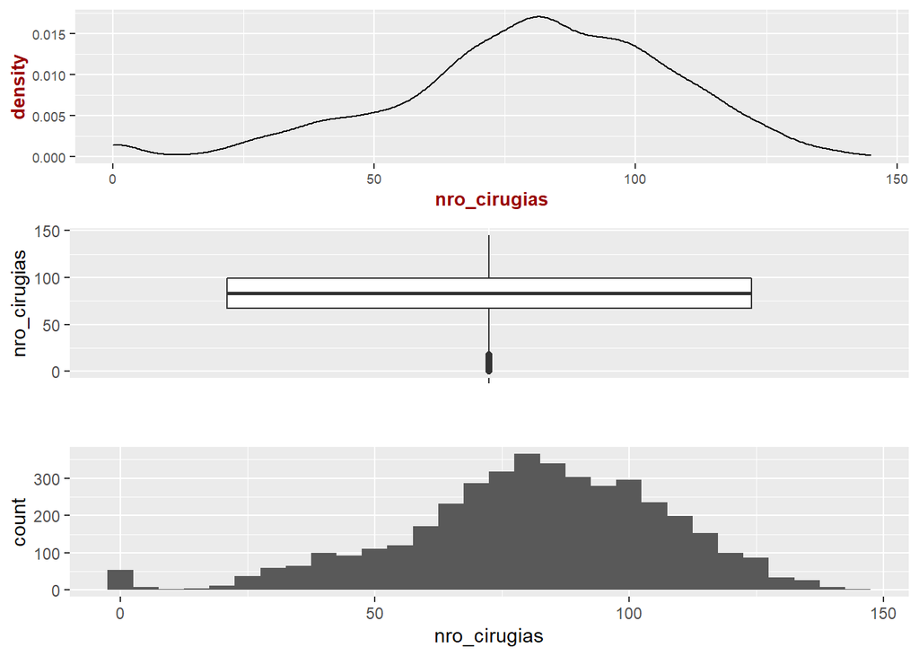

```r
attach(Base2)
d1 <- ggplot(data = Base2,
             aes(x = nro_cirugias)
             ) +
             geom_density() +
             labs(list(x = "nro_cirugias", y = "Densidad", color="dia_cirugia"))+
             theme(axis.title = element_text(face = "bold",
                                             colour = "#990000",
                                             size = 10),
                   axis.text = element_text(size = 7),
                   plot.title = element_text(size = rel(1.2),
                                             colour = "blue")
                   )
bp1 <- ggplot(data = Base2, aes(x = factor(""), y = nro_cirugias)) +
       geom_boxplot() +
       ylab("nro_cirugias") + xlab("")

h1 <-ggplot(data = Base2,aes(x = nro_cirugias)) +
     geom_histogram() +
     labs(list(x = "nro_cirugias", y = "Frecuencia"))

grid.arrange(d1,bp1,h1)
```

```r
mean(nro_cirugias)
```

```
## [1] 81.1135
```

```r
median(nro_cirugias)
```

```
## [1] 83
```

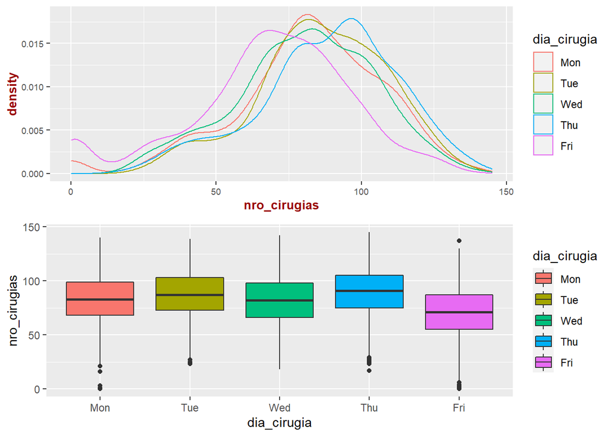

```r
attach(Base2)
d2 <- ggplot(data = Base2,
             aes(x = nro_cirugias, color=dia_cirugia)
             ) +
             geom_density() +
             labs(list(x = "nro_cirugias", y = "Densidad", color="dia_cirugia"))+
             theme(axis.title = element_text(face = "bold",
                                             colour = "#990000",
                                             size = 10),
                   axis.text = element_text(size = 7),
                   plot.title = element_text(size = rel(1.2),
                                             colour = "blue")
                   )
bp2 <- ggplot(data = Base2, aes(x = dia_cirugia, y = nro_cirugias)) +
       geom_boxplot(aes(fill = dia_cirugia)) +
  labs(list(x = "dia_cirugia", y = "nro_cirugias"))

grid.arrange(d2,bp2)
```

```r
attach(Base2)
Tabla<-Base2 %>%
  select(dia_cirugia,nro_cirugias) %>%
  group_by(dia_cirugia) %>%
  summarise(dias_atras=n(),
            Promedio=mean(nro_cirugias,na.rm = TRUE),.groups="drop")
print(Tabla)
```

```
## # A tibble: 5 × 3
##   dia_cirugia dias_atras Promedio
##   <fct>            <int>    <dbl>
## 1 Mon                799     81.7
## 2 Tue                833     86.3
## 3 Wed                816     80.6
## 4 Thu                816     88.6
## 5 Fri                833     68.6
```

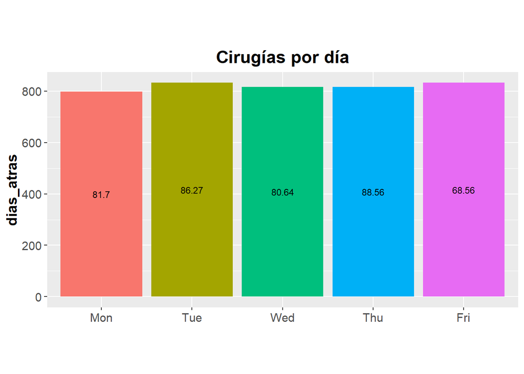

```r
Tabla$Promedio<-round(Tabla$Promedio,2)

ggplot(as.data.frame(Tabla),aes(dia_cirugia, dias_atras, fill=dia_cirugia)) +
  geom_bar(stat= "identity",show.legend = FALSE) +
  geom_text(aes(label=Promedio), position = position_stack(vjust = 0.5),size = 3)+
  theme (text = element_text(size=14)) +
  ggtitle ("Cirugías por día") +
  theme(plot.title = element_text(hjust = 0.5,face="bold"))+ # centra el título y en negrita
  theme (axis.title = element_text(face="bold", colour="black", size=rel(1.0))) + # formato a los ejes
  labs(x = NULL)+theme(aspect.ratio =0.5) #Tamaño de las barras
```

### **5. Conclusiones**

5.1 El volumen proyectado de cirugías diarias es de 83.

5.2 Los días de mayor volumen de cirugías son los días de lunes a jueves, con un promedio mayor a 80 cirugías diarias; mientras los días viernes son menor volumen con un promedio por debajo de 70 cirugías por día.

### **6. Recomendaciones**

Se recomienda la provisión de recursos y/o insumos médicos con un stock mínimo de acuerdo a las proyecciones de cirugías por día de la semana.